# Biostat M280 Homework 4

Due Mar 22 @ 11:59PM

Li Zhang Xueyao Gao Brian Hsiao Fanyu Zhang

For this homework, you can work as a team of size $\le 5$. You can create a new private GitHub repository for collaboration (need to add @Hua-Zhou and @juhkim111 as collaborators) or re-use the current repository of a team representative. For each question, your report should have a clear description of role of each team member, and Git log should reflect individual contribution to the project.

## Q1 Learn by doing

I found the [TensorFlow for R Blog](https://blogs.rstudio.com/tensorflow/) series at RStudio quite illuminating. Choose one blog that interests you and do following.

1. Reproduce the results in the blog.

   The blog is “Classifying physical activity from smartphone data” with html link: https://blogs.rstudio.com/tensorflow/posts/2018-07-17-activity-detection/ **

   Then reproduce the results in the blog as follows:

**Introduction**

[output not shown]

**Activities dataset**

```
The data used in this post come from the Smartphone-Based Recognition of Human Activities and Postural Transitions Data Set distributed by the University of California, Irvine.
```

```r
    dir.create("data")
    download.file(
      url = "http://archive.ics.uci.edu/ml/machine-learning-databases/00341/HAPT%20Data%20Set.zip",
      destfile = "data/HAPT.zip"
      )
    unzip("data/HAPT.zip", exdir = "data/HAPT")
```

**Activity labels**

The data has integer encodings for the activities which, while not important to the model itself, are helpful for use to see. Let’s load them first.

```r
    activityLabels <- read.table("data/HAPT/activity_labels.txt",
                                 col.names = c("number", "label"))
    activityLabels %>% kable(align = c("c", "l"))
```

| number | label |
| --- | --- |
| 1 | WALKING |
| 2 | WALKING_UPSTAIRS |
| 3 | WALKING_DOWNSTAIRS |
| 4 | SITTING |
| 5 | STANDING |
| 6 | LAYING |
| 7 | STAND_TO_SIT |
| 8 | SIT_TO_STAND |
| 9 | SIT_TO_LIE |
| 10 | LIE_TO_SIT |
| 11 | STAND_TO_LIE |
| 12 | LIE_TO_STAND |

Next, we load in the labels key for the RawData. This file is a list of all of the observations, or individual activity recordings, contained in the data set. The key for the columns is taken from the data README.txt.

```
Column 1: experiment number ID,
Column 2: user number ID,
Column 3: activity number ID,
Column 4: Label start point,
Column 5: Label end point.
```

Let’s take a look at the first 50 rows:

```r
    labels <- read.table("data/HAPT/RawData/labels.txt", col.names = c("experiment", "userId", "activity", "startPos", "endPos"))
    labels %>%
      head(50) %>%
      paged_table()
```

|  | experiment | userId | activity | startPos | endPos |
| --- | --- | --- | --- | --- | --- |
| 1 | 1 | 1 | 5 | 250 | 1232 |
| 2 | 1 | 1 | 7 | 1233 | 1392 |
| 3 | 1 | 1 | 4 | 1393 | 2194 |
| 4 | 1 | 1 | 8 | 2195 | 2359 |
| 5 | 1 | 1 | 5 | 2360 | 3374 |
| 6 | 1 | 1 | 11 | 3375 | 3662 |
| 7 | 1 | 1 | 6 | 3663 | 4538 |
| 8 | 1 | 1 | 10 | 4539 | 4735 |
| 9 | 1 | 1 | 4 | 4736 | 5667 |
| 10 | 1 | 1 | 9 | 5668 | 5859 |

[output cut: 40 more lines]

**File names**

Next, let’s look at the actual files of the user data provided to us in RawData

```r
    dataFiles <- list.files("data/HAPT/RawData")
    dataFiles %>%
      head()
```

```
## [1] "acc_exp01_user01.txt" "acc_exp02_user01.txt" "acc_exp03_user02.txt"
## [4] "acc_exp04_user02.txt" "acc_exp05_user03.txt" "acc_exp06_user03.txt"
```

There is a three-part file naming scheme. The first part is the type of data the file contains: either acc for accelerometer or gyro for gyroscope. Next is the experiment number, and last is the user Id for the recording. Let’s load these into a dataframe for ease of use later.

```r
    fileInfo <- data_frame(filePath = dataFiles) %>%
      filter(filePath != "labels.txt") %>%
      separate(filePath, sep = '_',
           into = c("type", "experiment", "userId"),
           remove = FALSE) %>%
      mutate(
        experiment = str_remove(experiment, "exp"),
        userId = str_remove_all(userId, "user|\\.txt")) %>%
      spread(type, filePath)

    fileInfo %>% head() %>% kable()
```

| experiment | userId | acc | gyro |
| --- | --- | --- | --- |
| 01 | 01 | acc_exp01_user01.txt | gyro_exp01_user01.txt |
| 02 | 01 | acc_exp02_user01.txt | gyro_exp02_user01.txt |
| 03 | 02 | acc_exp03_user02.txt | gyro_exp03_user02.txt |
| 04 | 02 | acc_exp04_user02.txt | gyro_exp04_user02.txt |
| 05 | 03 | acc_exp05_user03.txt | gyro_exp05_user03.txt |
| 06 | 03 | acc_exp06_user03.txt | gyro_exp06_user03.txt |

**Reading and gathering data**

Before we can do anything with the data provided we need to get it into a model-friendly format. This means we want to have a list of observations, their class (or activity label), and the data corresponding to the recording.

To obtain this we will scan through each of the recording files present in dataFiles, look up what observations are contained in the recording, extract those recordings and return everything to an easy to model with dataframe.

```r
    readInData <- function(experiment, userId){
      genFilePath = function(type) {
        paste0("data/HAPT/RawData/", type, "_exp",experiment,
               "_user", userId, ".txt")
        }
      bind_cols(
        read.table(genFilePath("acc"), col.names = c("a_x", "a_y", "a_z")),
        read.table(genFilePath("gyro"), col.names = c("g_x", "g_y", "g_z"))
      )
    }

    # Function to read a given file and get the observations contained along
    # with their classes.

    loadFileData <- function(curExperiment, curUserId) {
      # load sensor data from file into dataframe
      allData <- readInData(curExperiment, curUserId)

      extractObservation <- function(startPos, endPos){
        allData[startPos:endPos,]
        }
      # get observation locations in this file from labels dataframe
      dataLabels <- labels %>%
        filter(userId == as.integer(curUserId),
           experiment == as.integer(curExperiment))

      # extract observations as dataframes and save as a column in dataframe.
      dataLabels %>%
        mutate(data = map2(startPos, endPos, extractObservation)) %>%
        select(-startPos, -endPos)
      }
    # scan through all experiment and userId combos and gather data into a dataframe.
    allObservations <- map2_df(fileInfo$experiment, fileInfo$userId, loadFileData) %>%
      right_join(activityLabels, by = c("activity" = "number")) %>%
      rename(activityName = label)
    # cache work.
    write_rds(allObservations, "allObservations.rds")
    allObservations %>% dim()
```

```
## [1] 1214    5
```

**Exploring the data**

Now that we have all the data loaded along with the experiment, userId, and activity labels, we can explore the data set.

**Length of recordings**

Let’s first look at the length of the recordings by activity.

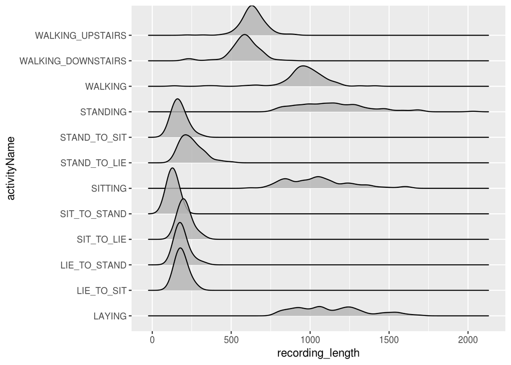

```r
    allObservations %>%
      mutate(recording_length = map_int(data,nrow)) %>%
      ggplot(aes(x = recording_length, y = activityName)) +
      geom_density_ridges(alpha = 0.8)
```

**Filtering activities**

Based on our work from above, let’s subset the data to just be of the activities of interest.

```r
    desiredActivities <- c(
  "STAND_TO_SIT", "SIT_TO_STAND", "SIT_TO_LIE",
  "LIE_TO_SIT", "STAND_TO_LIE", "LIE_TO_STAND")

    filteredObservations <- allObservations %>%
      filter(activityName %in% desiredActivities) %>%
      mutate(observationId = 1:n())

    filteredObservations %>% paged_table()
```

| experiment | userId | activity | data | activityName | observationId |
| --- | --- | --- | --- | --- | --- |
| 1 | 1 | 7 |  | STAND_TO_SIT | 1 |
| 2 | 1 | 7 |  | STAND_TO_SIT | 2 |
| 3 | 2 | 7 |  | STAND_TO_SIT | 3 |
| 4 | 2 | 7 |  | STAND_TO_SIT | 4 |
| 5 | 3 | 7 |  | STAND_TO_SIT | 5 |
| 6 | 3 | 7 |  | STAND_TO_SIT | 6 |
| 7 | 4 | 7 |  | STAND_TO_SIT | 7 |
| 8 | 4 | 7 |  | STAND_TO_SIT | 8 |
| 9 | 5 | 7 |  | STAND_TO_SIT | 9 |
| 10 | 5 | 7 |  | STAND_TO_SIT | 10 |

[output cut: 348 more lines]

So after our aggressive pruning of the data we will have a respectable amount of data left upon which our model can learn.

**Training/testing split**

Before we go any further into exploring the data for our model, in an attempt to be as fair as possible with our performance measures, we need to split the data into a train and test set. Since each user performed all activities just once (with the exception of one who only did 10 of the 12 activities) by splitting on userId we will ensure that our model sees new people exclusively when we test it.

```r
    # get all users
    userIds <- allObservations$userId %>% unique()

    # randomly choose 24 (80% of 30 individuals) for training
    set.seed(42) # seed for reproducibility
    trainIds <- sample(userIds, size = 24)

    # set the rest of the users to the testing set
    testIds <- setdiff(userIds,trainIds)

    # filter data.
    trainData <- filteredObservations %>%
      filter(userId %in% trainIds)

    testData <- filteredObservations %>%
      filter(userId %in% testIds)
```

**Visualizing activities**

Now that we have trimmed our data by removing activities and splitting off a test set, we can actually visualize the data for each class to see if there’s any immediately discernible shape that our model may be able to pick up on.

First let’s unpack our data from its dataframe of one-row-per-observation to a tidy version of all the observations.

```r
    unpackedObs <- 1:nrow(trainData) %>%
      map_df(function(rowNum){
        dataRow <- trainData[rowNum, ]
        dataRow$data[[1]] %>%
          mutate(
            activityName = dataRow$activityName,
            observationId = dataRow$observationId,
            time = 1:n() )
        }) %>%
      gather(reading, value, -time, -activityName, -observationId) %>%
      separate(reading, into = c("type", "direction"), sep = "_") %>%
      mutate(type = ifelse(type == "a", "acceleration", "gyro"))
```

Now we have an unpacked set of our observations, let’s visualize them!

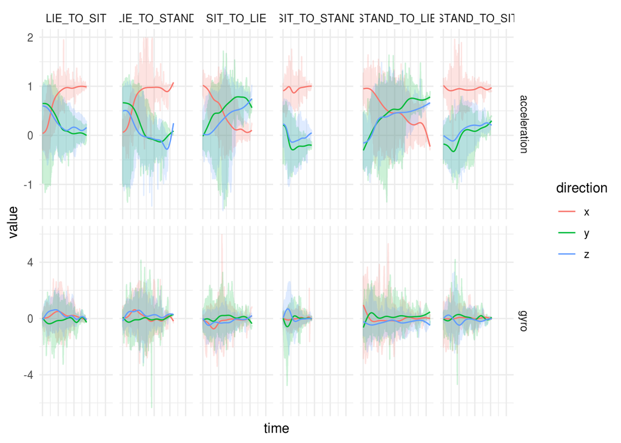

```r
    unpackedObs %>%
      ggplot(aes(x = time, y = value, color = direction)) +
      geom_line(alpha = 0.2) +
      geom_smooth(se = FALSE, alpha = 0.7, size = 0.5) +
      facet_grid(type ~ activityName, scales = "free_y") +
      theme_minimal() +
      theme( axis.text.x = element_blank() )
```

**Preprocessing**

Before we can train the neural network, we need to take a couple of steps to preprocess the data.

**Padding observations**

First we will decide what length to pad (and truncate) our sequences to by finding what the 98th percentile length is. By not using the very longest observation length this will help us avoid extra-long outlier recordings messing up the padding.

```r
    padSize <- trainData$data %>%
      map_int(nrow) %>%
      quantile(p = 0.98) %>%
      ceiling()
    padSize
```

```
## 98%
## 334
```

Now we simply need to convert our list of observations to matrices, then use the super handy pad_sequences() function in Keras to pad all observations and turn them into a 3D tensor for us.

```r
    convertToTensor <- . %>%
      map(as.matrix) %>%
      pad_sequences(maxlen = padSize)

    trainObs <- trainData$data %>% convertToTensor()
    testObs <- testData$data %>% convertToTensor()

    dim(trainObs)
```

```
## [1] 286 334   6
```

**One-hot encoding**

There’s one last thing we need to do before we can train our model, and that is turn our observation classes from integers into one-hot, or dummy encoded, vectors. Luckily, again Keras has supplied us with a very helpful function to do just this.

```r
    oneHotClasses <- . %>%
      {. - 7} %>%        # bring integers down to 0-6 from 7-12
      to_categorical() # One-hot encode

    trainY <- trainData$activity %>% oneHotClasses()
    testY <- testData$activity %>% oneHotClasses()
```

**Modeling**

**Architecture**

Since we have temporally dense time-series data we will make use of 1D convolutional layers. With temporally-dense data, an RNN has to learn very long dependencies in order to pick up on patterns, CNNs can simply stack a few convolutional layers to build pattern representations of substantial length. Since we are also simply looking for a single classification of activity for each observation, we can just use pooling to ‘summarize’ the CNNs view of the data into a dense layer. In addition to stacking two layer_conv_1d() layers, we will use batch norm and dropout to regularize the network.

```r
    input_shape <- dim(trainObs)[-1]
    num_classes <- dim(trainY)[2]
    filters <- 24     # number of convolutional filters to learn
    kernel_size <- 8  # how many time-steps each conv layer sees.
    dense_size <- 48  # size of our penultimate dense layer.

    # Initialize model
    model <- keras_model_sequential()
    model %>%
      layer_conv_1d(
        filters = filters,
        kernel_size = kernel_size,
        input_shape = input_shape,
        padding = "valid",
        activation = "relu") %>%
      layer_batch_normalization() %>%
      layer_spatial_dropout_1d(0.15) %>%
      layer_conv_1d(
        filters = filters/2,
        kernel_size = kernel_size,
        activation = "relu",) %>%
      # Apply average pooling:
      layer_global_average_pooling_1d() %>%
      layer_batch_normalization() %>%
      layer_dropout(0.2) %>%
      layer_dense(
        dense_size,
        activation = "relu"
        ) %>%
      layer_batch_normalization() %>%
      layer_dropout(0.25) %>%
      layer_dense(
        num_classes,
        activation = "softmax",
        name = "dense_output"
        )

    summary(model)
```

```
## ___________________________________________________________________________
## Layer (type)                     Output Shape                  Param #
## ===========================================================================
## conv1d_1 (Conv1D)                (None, 327, 24)               1176
## ___________________________________________________________________________
## batch_normalization_1 (BatchNorm (None, 327, 24)               96
## ___________________________________________________________________________
## spatial_dropout1d_1 (SpatialDrop (None, 327, 24)               0
## ___________________________________________________________________________
## conv1d_2 (Conv1D)                (None, 320, 12)               2316
## ___________________________________________________________________________
## global_average_pooling1d_1 (Glob (None, 12)                    0
## ___________________________________________________________________________
## batch_normalization_2 (BatchNorm (None, 12)                    48
## ___________________________________________________________________________
## dropout_1 (Dropout)              (None, 12)                    0
## ___________________________________________________________________________
## dense_1 (Dense)                  (None, 48)                    624
## ___________________________________________________________________________
## batch_normalization_3 (BatchNorm (None, 48)                    192
## ___________________________________________________________________________
## dropout_2 (Dropout)              (None, 48)                    0
## ___________________________________________________________________________
## dense_output (Dense)             (None, 6)                     294
## ===========================================================================
## Total params: 4,746
## Trainable params: 4,578
## Non-trainable params: 168
## ___________________________________________________________________________
```

**Training**

Now we can train the model using our test and training data. Note that we use callback_model_checkpoint() to ensure that we save only the best variation of the model (desirable since at some point in training the model may begin to overfit or otherwise stop improving).

```r
    # Compile model
    model %>% compile(
      loss = "categorical_crossentropy",
      optimizer = "rmsprop",
      metrics = "accuracy"
      )

    trainHistory <- model %>%
      fit(
        x = trainObs, y = trainY,
        epochs = 350,
        validation_data = list(testObs, testY),
        callbacks = list(
          callback_model_checkpoint("best_model.h5",
                                    save_best_only = TRUE)
          )
        )
```

**Evaluation**

Now that we have a trained model let’s investigate the errors that it made on our testing data. We can load the best model from training based upon validation accuracy and then look at each observation, what the model predicted, how high a probability it assigned, and the true activity label.

```r
    # dataframe to get labels onto one-hot encoded prediction columns
    oneHotToLabel <- activityLabels %>%
      mutate(number = number - 7) %>%
      filter(number >= 0) %>%
      mutate(class = paste0("V",number + 1)) %>%
      select(-number)

    # Load our best model checkpoint
    bestModel <- load_model_hdf5("best_model.h5")
    tidyPredictionProbs <- bestModel %>%
      predict(testObs) %>%
      as_data_frame() %>%
      mutate(obs = 1:n()) %>%
      gather(class, prob, -obs) %>%
      right_join(oneHotToLabel, by = "class")

    predictionPerformance <- tidyPredictionProbs %>%
      group_by(obs) %>%
      summarise(
        highestProb = max(prob),
        predicted = label[prob == highestProb]) %>%
      mutate(
        truth = testData$activityName,
        correct = truth == predicted
        )

    predictionPerformance %>% paged_table()
```

| obs | highestProb | predicted | truth | correct |
| --- | --- | --- | --- | --- |
| 1 | 0.9107305 | STAND_TO_SIT | STAND_TO_SIT | TRUE |
| 2 | 0.9604236 | STAND_TO_SIT | STAND_TO_SIT | TRUE |
| 3 | 0.9588248 | STAND_TO_SIT | STAND_TO_SIT | TRUE |
| 4 | 0.8728474 | STAND_TO_SIT | STAND_TO_SIT | TRUE |
| 5 | 0.9828817 | STAND_TO_SIT | STAND_TO_SIT | TRUE |
| 6 | 0.9989774 | STAND_TO_SIT | STAND_TO_SIT | TRUE |
| 7 | 0.9971061 | STAND_TO_SIT | STAND_TO_SIT | TRUE |
| 8 | 0.9988110 | STAND_TO_SIT | STAND_TO_SIT | TRUE |
| 9 | 0.9778462 | STAND_TO_SIT | STAND_TO_SIT | TRUE |
| 10 | 0.9842497 | STAND_TO_SIT | STAND_TO_SIT | TRUE |

[output cut: 62 more lines]

First, let’s look at how ‘confident’ the model was by if the prediction was correct or not.

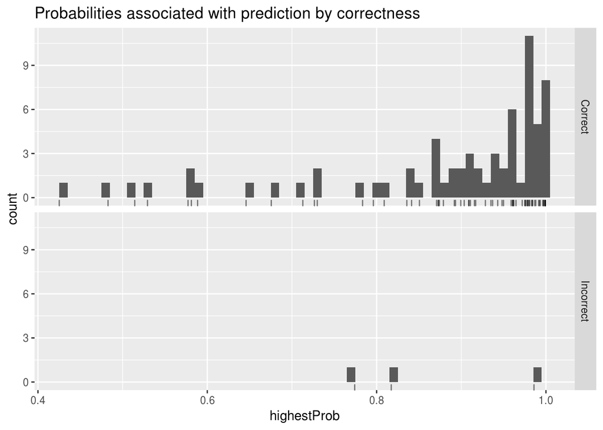

```r
    predictionPerformance %>%
      mutate(result = ifelse(correct, 'Correct', 'Incorrect')) %>%
      ggplot(aes(highestProb)) +
      geom_histogram(binwidth = 0.01) +
      geom_rug(alpha = 0.5) +
      facet_grid(result~.) +
      ggtitle("Probabilities associated with prediction by correctness")
```

Reassuringly it seems the model was, on average, less confident about its classifications for the incorrect results than the correct ones. (Although, the sample size is too small to say anything definitively.)

Let’s see what activities the model had the hardest time with using a confusion matrix.

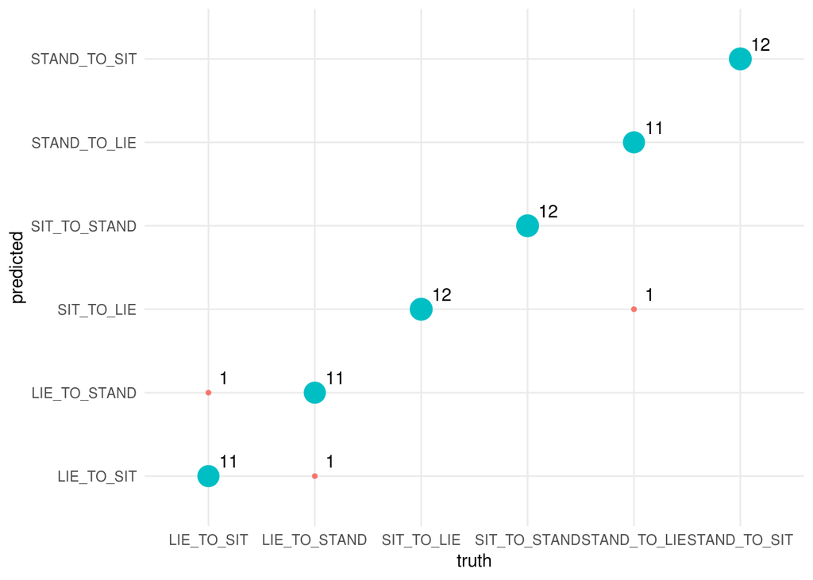

```r
    predictionPerformance %>%
      group_by(truth, predicted) %>%
      summarise(count = n()) %>%
      mutate(good = truth == predicted) %>%
      ggplot(aes(x = truth,  y = predicted)) +
      geom_point(aes(size = count, color = good)) +
      geom_text(aes(label = count),
                hjust = 0, vjust = 0, nudge_x = 0.1, nudge_y = 0.1) +
      guides(color = FALSE, size = FALSE) +
      theme_minimal()
```

We see that, as the preliminary visualization suggested, the model had a bit of trouble with distinguishing between LIE_TO_SIT and LIE_TO_STAND classes, along with the SIT_TO_LIE and STAND_TO_LIE, which also have similar visual profiles.

2. Make your own tweaks. For example, try different tuning parameter values and report what you found, or try a new data set, or apply the method to a new application.

Now let’s try some different parameter and see how’s new model performance.

```r
    input_shape <- dim(trainObs)[-1]
    num_classes <- dim(trainY)[2]
    filters_2 <- 36     # number of convolutional filters to learn
    kernel_size_2 <- 12  # how many time-steps each conv layer sees.
    dense_size_2 <- 72  # size of our penultimate dense layer.

    # Initialize model
    model_2 <- keras_model_sequential()
    model_2 %>%
      layer_conv_1d(
        filters = filters_2,
        kernel_size = kernel_size_2,
        input_shape = input_shape,
        padding = "valid",
        activation = "relu") %>%
      layer_batch_normalization() %>%
      layer_spatial_dropout_1d(0.15) %>%
      layer_conv_1d(
        filters = filters_2/2,
        kernel_size = kernel_size_2,
        activation = "relu",) %>%
      # Apply average pooling:
      layer_global_average_pooling_1d() %>%
      layer_batch_normalization() %>%
      layer_dropout(0.2) %>%
      layer_dense(
        dense_size_2,
        activation = "relu"
        ) %>%
      layer_batch_normalization() %>%
      layer_dropout(0.25) %>%
      layer_dense(
        num_classes,
        activation = "softmax",
        name = "dense_output"
        )

    summary(model_2)
```

```
## ___________________________________________________________________________
## Layer (type)                     Output Shape                  Param #
## ===========================================================================
## conv1d_3 (Conv1D)                (None, 323, 36)               2628
## ___________________________________________________________________________
## batch_normalization_4 (BatchNorm (None, 323, 36)               144
## ___________________________________________________________________________
## spatial_dropout1d_2 (SpatialDrop (None, 323, 36)               0
## ___________________________________________________________________________
## conv1d_4 (Conv1D)                (None, 312, 18)               7794
## ___________________________________________________________________________
## global_average_pooling1d_2 (Glob (None, 18)                    0
## ___________________________________________________________________________
## batch_normalization_5 (BatchNorm (None, 18)                    72
## ___________________________________________________________________________
## dropout_3 (Dropout)              (None, 18)                    0
## ___________________________________________________________________________
## dense_2 (Dense)                  (None, 72)                    1368
## ___________________________________________________________________________
## batch_normalization_6 (BatchNorm (None, 72)                    288
## ___________________________________________________________________________
## dropout_4 (Dropout)              (None, 72)                    0
## ___________________________________________________________________________
## dense_output (Dense)             (None, 6)                     438
## ===========================================================================
## Total params: 12,732
## Trainable params: 12,480
## Non-trainable params: 252
## ___________________________________________________________________________
```

**Training**

Now we can train the new model using our test and training data.

```r
    # Compile model
    model_2 %>% compile(
      loss = "categorical_crossentropy",
      optimizer = "rmsprop",
      metrics = "accuracy"
      )

    trainHistory_2 <- model_2 %>%
      fit(
        x = trainObs, y = trainY,
        epochs = 350,
        validation_data = list(testObs, testY),
        callbacks = list(
          callback_model_checkpoint("best_model_2.h5",
                                    save_best_only = TRUE)
          )
        )
```

**Evaluation**

Now that we have a trained model let’s investigate the errors that it made on our testing data. We can load the best model from training based upon validation accuracy and then look at each observation, what the model predicted, how high a probability it assigned, and the true activity label.

```r
    # dataframe to get labels onto one-hot encoded prediction columns
    oneHotToLabel_2 <- activityLabels %>%
      mutate(number = number - 7) %>%
      filter(number >= 0) %>%
      mutate(class = paste0("V",number + 1)) %>%
      select(-number)

    # Load our best model checkpoint
    bestModel_2 <- load_model_hdf5("best_model_2.h5")
    tidyPredictionProbs_2 <- bestModel_2 %>%
      predict(testObs) %>%
      as_data_frame() %>%
      mutate(obs = 1:n()) %>%
      gather(class, prob, -obs) %>%
      right_join(oneHotToLabel_2, by = "class")

    predictionPerformance_2 <- tidyPredictionProbs_2 %>%
      group_by(obs) %>%
      summarise(
        highestProb_2 = max(prob),
        predicted_2 = label[prob == highestProb_2]) %>%
      mutate(
        truth = testData$activityName,
        correct = truth == predicted_2
        )

    predictionPerformance_2 %>% paged_table()
```

| obs | highestProb_2 | predicted_2 | truth | correct |
| --- | --- | --- | --- | --- |
| 1 | 0.9322559 | STAND_TO_SIT | STAND_TO_SIT | TRUE |
| 2 | 0.9033210 | STAND_TO_SIT | STAND_TO_SIT | TRUE |
| 3 | 0.8195429 | STAND_TO_SIT | STAND_TO_SIT | TRUE |
| 4 | 0.7309386 | STAND_TO_SIT | STAND_TO_SIT | TRUE |
| 5 | 0.9524185 | STAND_TO_SIT | STAND_TO_SIT | TRUE |
| 6 | 0.9981529 | STAND_TO_SIT | STAND_TO_SIT | TRUE |
| 7 | 0.9966504 | STAND_TO_SIT | STAND_TO_SIT | TRUE |
| 8 | 0.9910506 | STAND_TO_SIT | STAND_TO_SIT | TRUE |
| 9 | 0.9800934 | STAND_TO_SIT | STAND_TO_SIT | TRUE |
| 10 | 0.9875793 | STAND_TO_SIT | STAND_TO_SIT | TRUE |

[output cut: 62 more lines]

First, let’s look at how ‘confident’ the model was by if the prediction was correct or not.

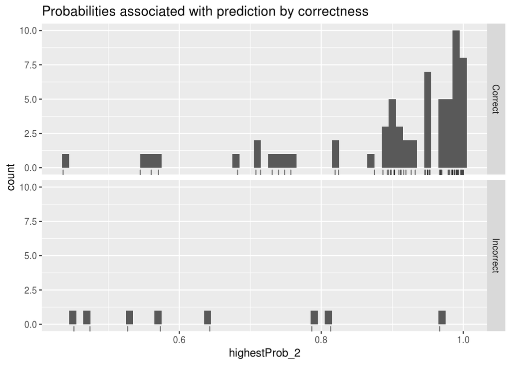

```r
    predictionPerformance_2 %>%
      mutate(result = ifelse(correct, 'Correct', 'Incorrect')) %>%
      ggplot(aes(highestProb_2)) +
      geom_histogram(binwidth = 0.01) +
      geom_rug(alpha = 0.5) +
      facet_grid(result~.) +
      ggtitle("Probabilities associated with prediction by correctness")
```

Then let’s see what activities the model had the hardest time with using a confusion matrix.

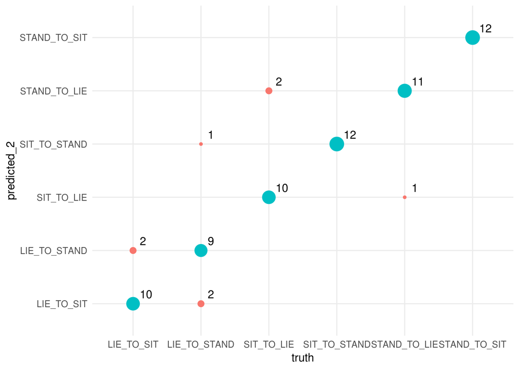

```r
    predictionPerformance_2 %>%
      group_by(truth, predicted_2) %>%
      summarise(count = n()) %>%
      mutate(good = truth == predicted_2) %>%
      ggplot(aes(x = truth,  y = predicted_2)) +
      geom_point(aes(size = count, color = good)) +
      geom_text(aes(label = count),
                hjust = 0, vjust = 0, nudge_x = 0.1, nudge_y = 0.1) +
      guides(color = FALSE, size = FALSE) +
      theme_minimal()
```

**Contribution**

Li and Xueyao worked on the reproduction of the model in the blog, Fanyu and Brian worked on tuning parameter values and building new model.

## Q2 Deep learning on smart phone

Professor May Wang in Department of Community Health Sciences (CHS) studies obesity in children and intervention strategies to prevent obesity. She asked me whether it is possible to develop an app such that a user takes a photo of a meal and the app will recognize and record the type of food (pizza, mac and cheese, burger, …).

Your job: produce a prototype app for iPhone or Android smart phone.

Resources:  
1. There are plenty of tutorials and YouTube clips on making apps for iPhone or Android.  
2. Google’s [Cloud Vision API](https://cloud.google.com/vision/) may supply an easy cloud solution.  
3. [TensorFlow Lite](https://www.tensorflow.org/lite) may provide an easy mobile solution.

**Solution**

For the food pitcure input, it could be downloaded from the web browser to local library in the simulator, then it could be recognized by our group app.

**Contribution**

Li and Fanyu worked on the exploration of developing the mobile app, including learning from tutorials online, maneuvering on the Google’s Could Vision API and the Firebase. Then we learned from examples online about how to develop an app on swift based on the Xcode software. Xueyao and Brian in addition worked on the improvement of the app, including the user interface, ViewController code. Finally, we together designed the app icon and launch interface to make it a more user-friendly app.